# Economic Data 2026 - Labs

Week 3

Aims: Familiarise yourself with Eurostat, national account data, and data manipulation in R.

Your country depends on the timing of your lab session:

- Monday: Norway
- Tuesday: Germany
- Wednesday: Spain
- Thursday: France

# Part 1

In this exercise we will calculate the growth rate of real GDP for your country since 1980. We can use the following formula to calculate the growth rate in percent:
$$\begin{equation}
g_t = 100 \times \left(\frac{\text{GDP}_t}{\text{GDP}_{t-1}}-1\right),
\end{equation}$$
where $t$ refers to the current period and $t-1$ the previous period. For this exercise, go through the following steps.

- Open an R script and save it as `lab_3.R`.
- Go to Eurostat and download data on GDP for your country for as many years as possible. **Hint**: What measure should you use? Chain-linking is a modern approach to calculating real GDP.
- Open the data in RStudio. Write the command for importing the dataset at the top of your script. Assign the dataset the name `df`.
- Keep only the columns in `df` with data on the year and GDP.
- Run the command `names(df)` in the console. What does it return?
- Rename the columns in your dataset to `year` and `gdp`. **Hint**: To rename the column containing data on year write `names(df)[1] <- 'year'`.
- Keep only observations after 1979.
- Run the command `nrow(df)` in the console. What does it return?
- Run the command `df$gdp[-1]` and `df$gdp[-nrow(df)]` in the console. Explain what these commands return.
- Generate a new column in `df` that is equal to the lagged GDP variable (that is $\text{GDP}_{t-1}$). Give this column the name `gdp_1`. **Hint**: The lagged variable can be generated using the command `c(NA, df$gdp[-nrow(df)])`.
- Generate a new column in `df` that is equal to the GDP growth rate. Give this column the name `gdp_g`.
- Generate a new column equal to one if the growth rate of GDP is greater than $0$ and zero otherwise. Give this column the name `positive`. **Hint**: Run the command `ifelse(df$gdp_g > 0, 'positive', 'negative')`.
- Run the command `colors <- ifelse(df$positive == 'positive', 'skyblue', 'lightcoral')`. Then use the commands below to construct the plot.

```r
barplot(df$gdp_g, names.arg = df$year, col = colors, border = NA,
        main = "The growth rate of GDP for the UK, 1980-2019",
        sub = "Real GDP 2015 national currency (chain linked).
               Source: Eurostat (nama_10_gdp)",
        xlab = "Year",
        ylab = "Growth rate",
        cex.main = 0.9,
        cex.sub = 0.7,
        cex.lab = 0.8,
        cex.names = 0.7)
```

- Discuss your findings by writing a comment in your script. What are the most striking features from the plot? **Hint**: Use `#`

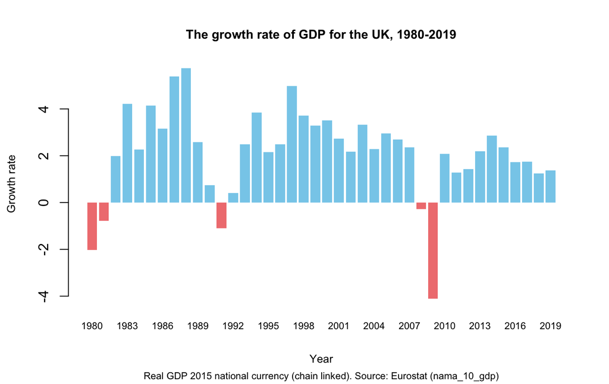

# Part 2

In this exercise we will plot the value-added share across different industries according to the NACE classification. To reproduce the chart below, follow the steps below.

- Go to Eurostat and download data on the value added by industry and total value added for your country and the most recent year. *Hint*: Annual national accounts (Gross value added and income by A*10 industry breakdowns). The classifications are given in the below chart.
- Load the dataset into R and assign it the name `nace`.
- Keep the columns containing the year, industry classification, and value-added.
- Rename the name containing information on the year to `year` and the column on value added `v_added`.
- Sum the value added of every industry. **Hint**: Do not sum the row containing the total.
- Generate a new column called `share` which gives the value added as a share of the total value added.
- Remove the row containing the total.
- Construct the plot below:

```r
barplot(height = nace$share, names.arg = nace$nace_r2,
        col = "skyblue", border = "black",
        main = "Value Added Share in the UK by NACE Category (2019)",
        sub = "Source: Eurostat (nama_10_a10)",
        ylab = "Share (%)", xlab = "NACE Category",
        ylim = c(0, max(nace$share) + 0.05))
```

- Comment on the plot in your script. What are the sectors of the economy of your country that account for the highest and lowest value added?

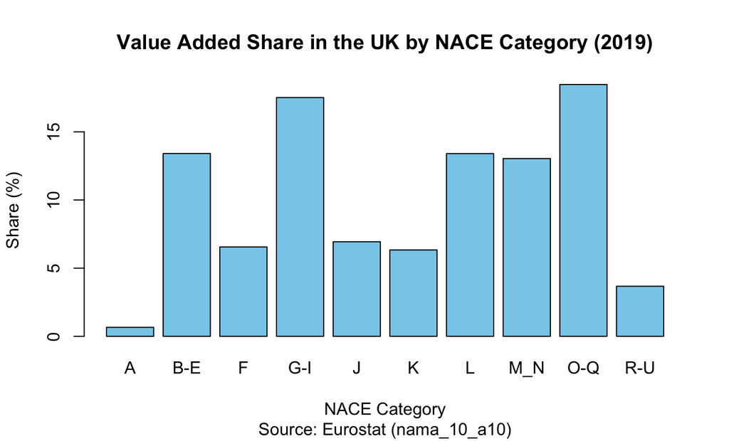

# Part 3

Continue working on mini project 1.